# Practical 4: Introduction to Monte Carlo simulation

Computational Finance with Python

Introduction to Monte Carlo simulation and generation of random numbers in Python.

Lecturer

Institution

[Alet Roux](https://www.york.ac.uk/maths/staff/alet-roux/)

[Department of Mathematics](https://maths.york.ac.uk)

University of York

The aim of this practical is to familiarise ourselves with the main ideas of (plain) Monte Carlo simulation, and practice Python functionality for generating random numbers.

# 1 Simulating Brownian motion and Black-Scholes stock prices

The purpose of the first two exercises is to practice generating random numbers in Python based on the material covered in the lectures. You can also consult the NumPy documentation (NumPy Developers (2022)) if needed.

**Exercise 1** Write code to produce $n$ simulations of the standard normal ($N(0,1)$) distribution. Choose a large value of $n$ (at least 1000). Then use the code provided to compare the histogram of the simulated values with the normal density function.

```python
import numpy as np
import math

# generate sample
# insert code here
sample # NumPy array containing vector of samples

# plot histogram
import matplotlib.pyplot as plt
fig, ax = plt.subplots(figsize = (12,7))
ax.hist(sample, bins='auto', density=True, align='mid', rwidth=0.8, label="Relative histogram")

# generate and plot probability density function
from scipy.stats import norm
rv = norm()
maxx = max(abs(sample))
x = np.linspace(-maxx, maxx, 10000)
ax.plot(x, rv.pdf(x), color="red", label="Density function")

# plot grid and legend
ax.xaxis.grid(True)
ax.yaxis.grid(True)
ax.legend()
```

*Solution 1*.

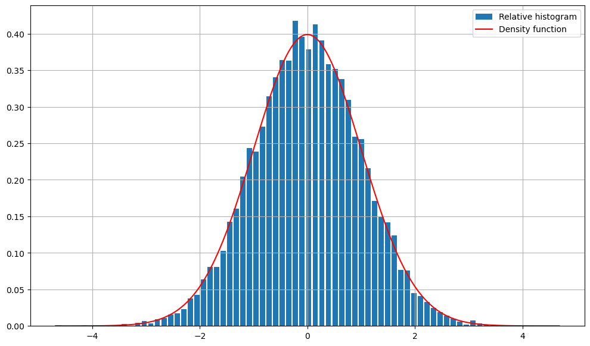

```python
import numpy as np
import math

# generate sample
n = 10000
rng = np.random.default_rng (seed = 30)
sample = rng.standard_normal(n)

# plot histogram
import matplotlib.pyplot as plt
fig, ax = plt.subplots(figsize = (12,7))
ax.hist(sample, bins='auto', density=True, align='mid', rwidth=0.8, label="Relative histogram")

# generate and plot probability density function
from scipy.stats import norm
rv = norm()
maxx = max(abs(sample))
x = np.linspace(-maxx, maxx, 200)
ax.plot(x, rv.pdf(x), color="red", label="Density function")

# plot grid and legend
ax.xaxis.grid(True)
ax.yaxis.grid(True)
ax.legend()
```

**Exercise 2** Write code to produce $n$ simulations of the Black-Scholes stock price
$$S_T = S_0 e^{(r-\frac{1}{2}\sigma^2)T + \sigma W^Q_T},$$
where $W^Q_T\sim N(0,T)$ and $S_0 = 50$, $r=0.05$, $\sigma=0.1$ and $T=0.5$.

Choose a large value of $n$ (at least 1000). Then use the code provided to compare the histogram of the simulated values with the lognormal density function.

Hint: It is a good idea to start with a smaller value of $n$ until you are sure that your formulae are correct.

```python
# generate sample
# insert code here
sample # NumPy array containing vector of samples

# plot histogram
fig, ax = plt.subplots(figsize = (12,7))
ax.hist(sample, bins='auto', density=True, align='mid', rwidth=0.8, label="Relative histogram")

# generate and plot probability density function
from scipy.stats import lognorm
mean = math.log(S0) + (r - 0.5*sigma**2)*T
sd = sigma*math.sqrt(T)
rv = lognorm(sd, scale = math.exp(mean))
x = np.linspace(min(sample), max(sample), 10000)
ax.plot(x, rv.pdf(x), color="red", label="Density function")

# plot grid and legend
ax.xaxis.grid(True)
ax.yaxis.grid(True)
ax.legend()
```

*Solution 2*.

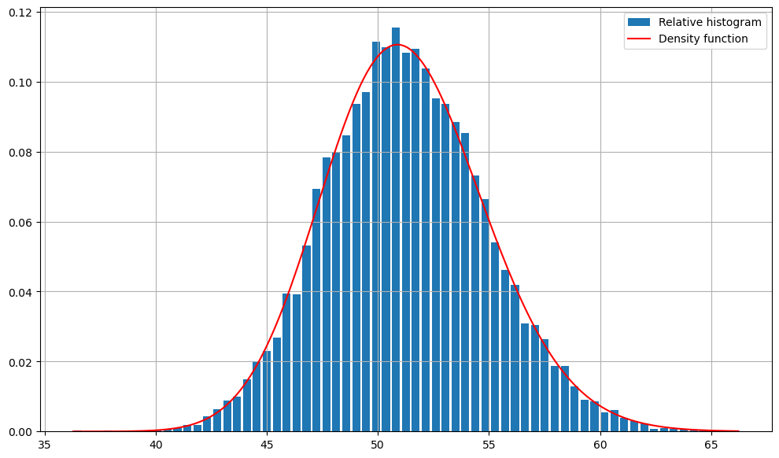

```python
# model parameters
S0 = 50
r = 0.05
sigma = 0.1
T = 0.5

# generate sample and produce histogram
n = 10000
sample = rng.lognormal(math.log(S0) + (r - 0.5*sigma**2)*T, sigma*math.sqrt(T), n)

# plot histogram
fig, ax = plt.subplots(figsize = (12,7))
ax.hist(sample, bins='auto', density=True, align='mid', rwidth=0.8, label="Relative histogram")

# generate and plot probability density function
from scipy.stats import lognorm
mean = math.log(S0) + (r - 0.5*sigma**2)*T
sd = sigma*math.sqrt(T)
rv = lognorm(sd, scale = math.exp(mean))
x = np.linspace(min(sample), max(sample), 200)
ax.plot(x, rv.pdf(x), color="red", label="Density function")

# plot grid and legend
ax.xaxis.grid(True)
ax.yaxis.grid(True)
ax.legend()
```

# 2 Digital put option

Assume that the underlying stock price follows the Black-Scholes model, in other words,
$$S_T = S_0 e^{(r-\frac{1}{2}\sigma^2)T + \sigma W^Q_T},$$
where $W^Q$ is a Brownian motion under the risk-neutral measure $Q$ and $r$ is the risk-free interest rate and $\sigma>0$ is the volatility of the model.

We consider a digital put option with maturity $T$ and payoff $h(S_T)$, where
$$h(S_T) =
\begin{cases}
1 & \text{if } S_T \le K, \\
0 & \text{if } S_T > K.
\end{cases}$$
The theoretical price at time 0 of this put is
$$P = e^{-rT}(1 - \Phi(d_-)),$$
where $\Phi$ is the cumulative distribution function of the standard normal distribution and
$$d_- = \frac{1}{\sigma\sqrt{T}}(\ln (S_0/K) + (r-\tfrac{1}{2}\sigma^2)T)$$
.

Use the test values $S_0=40$, $r=0.03$, $\sigma=0.2$, $K=45$, $T=0.25$, $n=1000$ in the following exercises.

**Exercise 3** Write a function to produce a Monte Carlo estimate for the price at time $0$ of a digital put option with maturity $T$.

The arguments of the function should be $S_0$, $r$, $\sigma$, $K$, $T$ and the number of simulations $n$. The function should return the estimate as well as its standard error.

Hint: There are a number of different ways to implement the calculation of the payoff.

```python
# Insert code here
```

*Solution 3*.

```python
def MC_digital_put (S0, r, sigma, K, T, n):
    """Monte Carlo estimation of price of digital put in Black-Scholes model.
    Output: estimate, standard_error"""

    rng = np.random.default_rng(seed = 40)
    mean = math.log(S0) + (r - 0.5*sigma**2)*T
    sd = sigma*math.sqrt(T)
    S = rng.lognormal(mean, sd, n)

    payoff = lambda x: 1 if x<=K else 0

    X = math.exp(-r*T)*np.vectorize(payoff, otypes=[np.float64])(S)

    estimate = np.mean(X)
    SE = np.std(X)/math.sqrt(n)

    return estimate, SE
```

**Exercise 4** Write code to calculate the theoretical price of the digital put option for the test values. Then compare the theoretical value with the estimate produced by your function.

```python
# Insert code here
```

*Solution 4*.

```python
# model parameters
S0 = 40
r = 0.03
sigma = 0.2
K = 45
T = 0.25
n = 1000

from scipy.stats import norm

dminus = (math.log(S0/K) + (r-0.5*sigma**2)*T)/sigma/math.sqrt(T)
price = math.exp(-r*T) * (1 - norm.cdf(dminus))

print("Theoretical price of digital put option:", price)

estimate, SE = MC_digital_put (S0, r, sigma, K, T, n)

print ("Monte Carlo estimate of digital put price:",estimate)
print ("Standard error:",SE)
```

```
Theoretical price of digital put option: 0.8689682264413452
Monte Carlo estimate of digital put price: 0.8664769918571077
Standard error: 0.010450853833813348
```

Once you have completed this task, you are ready to start Assignment 2.

## References

NumPy Developers. 2022. “Random Generator.” https://numpy.org/doc/stable/reference/random/generator.html.